# Project 5

Benjamin Draves

### Exercise 1

#### (a)

Consider the hidden Markov model $(X_i, Y_i)_{i=1}^{n=200}$ where $X_i\in \{1,2,3\}$ and $Y_i|X_i = s\sim N(\mu_s,\sigma_s^2)$. First we calculate the forward probabilities which are given by the following.

$$\begin{align*}
f_1(x_1) &= \mathbb{P}(X_1,Y_1)\\
f_2(x_2) &= \mathbb{P}(X_2,Y_1, Y_2)\\
&\vdots\\
f_i(x_i) &= \mathbb{P}(X_i,Y_1, \ldots, Y_i)\\
\end{align*}$$

In practice we calculate the log of these probabilities.

$$\begin{align*}
\widetilde{f}_1(x_1) &= \log[\mathbb{P}(X_1,Y_1)]\\
\widetilde{f}_2(x_2) &= \log[\mathbb{P}(X_2,Y_1, Y_2)]\\
&\vdots\\
\widetilde{f}_i(x_i) &= \log[\mathbb{P}(X_i,Y_1, \ldots, Y_i)]\\
\end{align*}$$

```r
# soft max (log-sum-exp) of vector `x`
LOGEPS <- log(.Machine$double.eps / 2)
lse <- function (x) {
  m <- max(x); x <- x - m
  m + log(sum(exp(x[x > LOGEPS])))
}

#Set variables for this algorithm

logI <- log(c(0, 1, 0)) # initial probabilities
logP <- matrix(log(c(0.50, 0.50, 0, 0.05, 0.90, 0.05, 0, 0.5, 0.5)),
               byrow = TRUE,
               nrow = 3) # Transition probs
Y <- cgh$log_ratio
logPYX <- matrix(c(dnorm(Y, mean = -1, sd = .7, log = TRUE),
                 dnorm(Y, mean = 0, sd = .5, log = TRUE),
                 dnorm(Y, mean = 1, sd = .7, log = TRUE)),
               nrow = 200,
               ncol = 3) # log[ P( Y_i | X_i = x) ]

forward <- function (s, logI, logP, logE) {
  n <- length(s); ns <- length(logI) #get dimensions
  f <- matrix(nrow = n, ncol = ns)
  f[1,] <- logI + logPYX[1,]
  for (i in 2:n) # for each position in sequence
    for (j in 1:ns) # for each X_i
      f[i, j] <- lse(f[i - 1,] + logP[,j]) + logPYX[i,j]
  f
}
f <- forward(Y, logI, logP, logPYX)
knitr::kable(as.data.frame(tail(f)))
```

|  | V1 | V2 | V3 |
| --- | --- | --- | --- |
| [195,] | -196.6476 | -191.5936 | -193.8472 |
| [196,] | -195.0963 | -194.1988 | -198.8496 |
| [197,] | -196.8685 | -194.3669 | -199.0164 |
| [198,] | -197.4882 | -195.3724 | -200.4511 |
| [199,] | -200.1735 | -195.9747 | -199.2230 |
| [200,] | -200.9410 | -196.3838 | -199.8068 |

Now that we have calculated these probabilities, we can find $\log\mathbb{P}(Y)$ through the following calculations.

$$\begin{align*}
\mathbb{P}(Y) &= \sum_{x_{200}}\mathbb{P}(X_{200}, Y) = \sum_{x_{200}}f_{200}(x_{200})\\
\log\mathbb{P}(Y) &= \log \sum_{x_{200}}\exp\left\{\log\mathbb{P}(X_{200}, Y)\right\} = \log\sum_{x_{200}=1}^3\exp\left\{\widetilde{f}_{200}(x_{200})\right\} = lse(\vec{\widetilde{f}}_{200}(x_{200}))
\end{align*}$$

Hence we see that taking the *lse* of the final row of the forward probabilities we can arrive at our final solution.

```r
logPY <- lse(f[200,])
logPY
```

```
## [1] -196.3416
```

#### (b)

```r
# compute most likely assignment of states given data (MAP)
viterbi <- function (s, logI, logP, logE) {

  n <- length(s); ns <- length(logI) # = nrow(logE) = nrow(logP)
  m <- matrix(nrow = n, ncol = ns) # maxima
  b <- matrix(nrow = n, ncol = ns) # backtrack pointers

  # recurse
  m[1,] <- logI + logPYX[1,]
  for (i in 2:n) { # for each position in sequence
    for (j in 1:ns) { # for each X_i
      u <- m[i - 1,] + logP[,j]
      m[i, j] <- max(u) + logPYX[i,j]
      b[i - 1, j] <- which.max(u)
    }
  }
  # backtrack
  v <- numeric(n)
  v[n] <- which.max(m[n,]) # b[n]
  for (i in (n - 1):1)
    v[i] <- b[i, v[i + 1]]
  list(m = m, b = b, seq = v)
}

res <- viterbi(Y, logI, logP, logPYX)
xhat <- res$seq
```

Now that we have calculated $\widehat{X}$ we can calculate $\log\mathbb{P}(\widehat{X}|Y)$ as follows.

$$\begin{align*}
\mathbb{P}(\widehat{X}|Y) &= \frac{\mathbb{P}(Y|\widehat{X})\mathbb{P}(\widehat{X})}{\mathbb{P}(Y)}\\
\log\mathbb{P}(\widehat{X}|Y) &= \log\mathbb{P}(Y|\widehat{X}) + \log\mathbb{P}(\widehat{X}) - \log\mathbb{P}(Y) \\
&= \sum_{i = 1}^n\log\mathbb{P}(Y_i|\widehat{X}_i) + \log\mathbb{P}(\widehat{X}) - \log\mathbb{P}(Y)
\end{align*}$$

Notice here we used the fact that given $\widehat{X}_i$ the $Y_i$ are independent. Moreover, we know the distribution of $Y_i|\widehat{X}_i$, can calculate $\log\mathbb{P}(\widehat{X}) = \sum_{i=1}^{n-1}\log\mathbb{P}(X_i +1|X_i)$ from the Markov chain transition probabilities, and we’ve already calculated $\log\mathbb{P}(Y)$ in part a. Hence we can calculate the above as follows.

```r
#calculate log P(Y|Xhat)
lPYX <- sum(logPYX[cbind(1:200, xhat)])

#calculate log P(Xhat)
lPX <- 0
for(i in 2:length(xhat)) lPX <- lPX + logP[xhat[i-1],xhat[i]]

#calculate solution
logPXY <- lPYX + lPX - logPY
logPXY
```

```
## [1] -16.5959
```

#### (c)

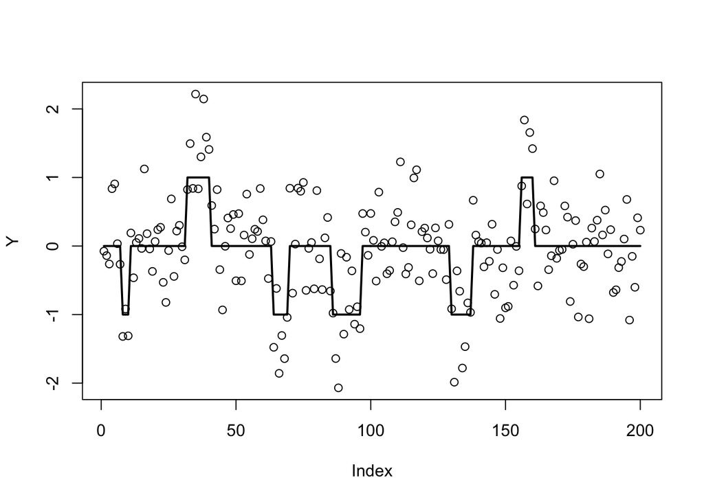

```r
plot(Y)
mu <- c(-1,0,1)
points(mu[xhat],
       type = "l",
       lwd = 2)
```

Here we see that the HMM fits the data reasonably well. Due to the high variance of the $Y_i$, it is difficult for the model to detect when the underlying chain states are different from 2. Therefore, the majority of these states are estimates to be $2$ corresponding with $\widehat{Y}_i = 0$ for the majority of the model. The model does however pick up clear trends in change especially for duplications in the (30,50) region and deletions in the $(80,100)$ region. The model does fairly well throughout but could possibly be overfitting in some of the small regions. In general, this model fits the data well.

#### (d)

Recall that by definition $f_{i}(x) = \mathbb{P}(X_{i}, Y_{1} = y_1,\ldots, Y_i = y_i)$. Hence $\mathbb{P}(x_{200}) = \mathbb{P}(X_{200}, Y = \vec{y})$. Therefore, we have

$$\begin{align*}
\mathbb{P}(X_{200} = 2|Y) &= \frac{f_{200}(2)}{\mathbb{P}(Y)}\\
\log(\mathbb{P}(X_{200} = 2|Y)) &= \log(f_{200}(2)) - \log(\mathbb{P}(Y))
\end{align*}$$
Notice however this doesn’t change based on the state. Hence, using the numbers we’ve already calculated we can find the probabilities of each state ending as follows.
$$\begin{align*}
\mathbb{P}(X_{200} = 2|Y) &= \exp\left\{\widetilde{f}_{200}(x) - \log\mathbb{P}(Y)\right\}\\
\frac{\mathbb{P}(X_{200} = 1|Y)}{\mathbb{P}(X_{200} = 3|Y)} &= \exp\left\{\widetilde{f}_{200}(1) - \widetilde{f}_{200}(3)\right\}\\
\end{align*}$$

```r
lp1 <- f[200, 1] - logPY
lp2 <- f[200, 2] - logPY
lp3 <- f[200, 3] - logPY

exp(lp2)
```

```
## [1] 0.9586747
```

```r
exp(lp1 - lp3)
```

```
## [1] 0.3216633
```

Therefore we see that the probability of the last prob being normal is 0.9586747 and is 0.3216633 times more likely to be deleted than duplicated.

### Exercise 2

#### (a)

$$\begin{align*}
\mathbb{P}(\theta_j|\beta_0, \beta, \theta_{[-j]}, Y) &\propto \mathbb{P}(\beta_0, \beta, \theta_{[-j]}, Y|\theta_j)\mathbb{P}(\theta_j)\\
&\propto\mathbb{P}(\beta_0, \beta, Y|\theta_{[-j]}, \theta_j)\mathbb{P}(\theta_{[-j]}|\theta_j)\mathbb{P}(\theta_j)\\
&\propto\mathbb{P}(\beta_0, \beta, Y|\theta)\mathbb{P}(\theta)\\
&\propto\mathbb{P}(Y|\beta_0,\beta)\mathbb{P}(\beta|\theta)\mathbb{P}(\beta_0)\mathbb{P}(\theta)
\end{align*}$$

Now recall that we can drop any probability statement that does not include the $\theta_j$ of interest. Hence, with a little more work we see that

$$\begin{align*}
\mathbb{P}(Y|\beta_0,\beta)\mathbb{P}(\beta|\theta)\mathbb{P}(\beta_0)\mathbb{P}(\theta) &\propto \Pi_{j = 1}^{p}\mathbb{P}(\beta_j|\theta_j)\mathbb{P}(\theta)\\
&\propto \mathbb{P}(\beta_j|\theta_j)\mathbb{P}(\theta)\\
&\propto \sigma^2(\theta_j)^{-1/2}\exp\left\{-\frac{\beta_j^2}{2\sigma^2(\theta_j)}\right\}\exp\left\{\frac{h}{2}\sum_{u=1}^p(2\theta_u - 1)+\frac{1}{T}\sum_{(u,v)\in G}(2\theta_u -1)(2\theta_v-1)\right\}\\
&\propto \sigma^2(\theta_j)^{-1/2}\exp\left\{-\frac{\beta_j^2}{2\sigma^2(\theta_j)} + \frac{h}{2}\sum_{u=1}^p(2\theta_u - 1)+\frac{1}{T}\sum_{(u,v)\in G}(2\theta_u -1)(2\theta_v-1)\right\}\\
\end{align*}$$

Now, again, we can drop all terms not including $\theta_j$. Notice that for the sum over the imposed graph $G$, this means that we only sum over pairs $(j,v)\in G$. This set, however, is just the neighbors of $j$, $N_j$. Hence we can reduce this term further as follows.

$$\begin{align*}
\mathbb{P}(\beta_j|\theta_j)\mathbb{P}(\theta)&\propto \sigma^2(\theta_j)^{-1/2}\exp\left\{-\frac{\beta_j^2}{2\sigma^2(\theta_j)} + \frac{h}{2}\sum_{u=1}^p(2\theta_u - 1)+\frac{1}{T}\sum_{(u,v)\in G}(2\theta_u -1)(2\theta_v-1)\right\}\\
&\propto \sigma^2(\theta_j)^{-1/2}\exp\left\{-\frac{\beta_j^2}{2\sigma^2(\theta_j)} + \frac{h}{2}(2\theta_j - 1)+\frac{1}{T}\sum_{v\in N_j}(2\theta_j -1)(2\theta_v-1)\right\}\\
&\propto \sigma^2(\theta_j)^{-1/2}\exp\left\{-\frac{\beta_j^2}{2\sigma^2(\theta_j)} + h\theta_j - \frac{h}{2} + \frac{2}{T}\theta_j\sum_{v\in N_j}(2\theta_v-1)-\frac{1}{T}\sum_{v\in N_j}(2\theta_v-1)\right\}\\
&\propto \sigma^2(\theta_j)^{-1/2}\exp\left\{-\frac{\beta_j^2}{2\sigma^2(\theta_j)} + h\theta_j + \frac{2}{T}\theta_j\sum_{v\in N_j}(2\theta_v-1)\right\}\\
&\propto \sigma^2(\theta_j)^{-1/2}\exp\left\{-\frac{\beta_j^2}{2\sigma^2(\theta_j)} + \theta_j\left(h + \frac{2}{T}\sum_{v\in N_j}(2\theta_v-1)\right)\right\}\\
\end{align*}$$

#### (b)

Here we see that the function
$$\begin{align*}
\beta_0^{(t+1)} = \text{step_laplace_mh}(\beta_0^{(t)}; Y, 1_n , X\beta^{(t)}, 0, 0)
\end{align*}$$
corresponds to the model
$$\begin{align*}
Y_i|\beta &\overset{ind}{\sim} \text{Bern}[\text{logit}^{-1}((1_n)_i\beta + X\beta^{(t)})]\\
\beta &\sim N(0, \infty)
\end{align*}$$

Recall that in the Gibbs framework, at this step in the algorithm we condition on $\theta^{(t+1)}$ and $\beta^{(t)}$ and try to estimate $\beta_0^{(t+1)}$. Well, taking $\beta = \beta_0$, we see that $\beta\sim N(0,\infty)$ is equivalent to $\mathbb{P}(\beta_0)\propto 1$. Moreover, we see that the $Y_i$ are conditional distributed as follows

$$\begin{align*}
Y_i|\beta_0 &\overset{ind}{\sim} \text{Bern}[\text{logit}^{-1}(\beta_0 + X\beta^{(t)})]\\
\mathbb{P}(\beta_0) &\propto 1
\end{align*}$$

This model is exactly the (t+1) Gibbs step for sampling $\beta_0^{(t+1)}$. Hence we can use the step_laplace_mh routine to sample $\beta_0^{(t)}$. Following a similar argument for $\beta_j^{(t+1)}$, we have

$$\begin{align*}
\beta_j^{(t+1)} = \text{step_laplace_mh}(&\beta_j^{(t)}; Y, X_j, 1_n\beta_0^{(t+1)} + X_{1:(j-1)}\beta_{1:(j-1)}^{t+1}\\&+ X_{(j+1):p}\beta_{(j+1):p}^{t}, 0, \frac{1 - \theta_j^{(t+1)}}{\tau_0^2} + \frac{\theta_j^{(t+1)}}{\tau^2})
\end{align*}$$
corresponds to the model
$$\begin{align*}
Y_i|\beta &\overset{ind}{\sim} \text{Bern}\left[\text{logit}^{-1}\left((X_j)_i\beta + 1_n\beta_0^{(t+1)} + X_{1:(j-1)}\beta_{1:(j-1)}^{t+1}+ X_{(j+1):p}\beta_{(j+1):p}^{t}\right)\right]\\
\beta &\sim N\left(0, \left(\frac{1 - \theta_j^{(t+1)}}{\tau_0^2} + \frac{\theta_j^{(t+1)}}{\tau^2}\right)^{-1}\right)
\end{align*}$$

Recall that in the Gibbs framework, at this step in the algorithm we condition on $\theta^{(t+1)}$, $\beta_{1:(j-1)}^{(t+1)}$, $\beta_{(j+1):p}^{(t)}$ and try to estimate $\beta_j^{(t+1)}$. Well, taking $\beta = \beta_j$, we see that as $\theta_j^{t} = 0,1$ that $\beta_j|\theta_j^{(t+1)} = 1\sim N(0, \tau^2)$ and $\beta_j|\theta_j^{(t+1)} = 1\sim N(0, \tau_0^2)$. Notice this is the exact prior we specified above for $\beta_j|\theta_j$. As we are in the Gibbs framework, we implicitly condition on $\theta_j$ and hence these are the same prior distributions. Moreover, we see that the $Y_i$ are conditional distributed as follows

$$\begin{align*}
Y_i|\beta &\overset{ind}{\sim} \text{Bern}[\text{logit}^{-1}((1_n^T)_i\beta_0^{(t+1)} + X_{1:(j-1)}\beta_{1:(j-1)}^{T} + X_j\beta_j + X_{(j+1):p}\beta_{(j+1):p}^{(t-1)})]\\
\beta_j &\sim N\left(0, \left(\frac{1 - \theta_j^{(t+1)}}{\tau_0^2} + \frac{\theta_j^{(t+1)}}{\tau^2}\right)^{-1}\right)
\end{align*}$$

Notice here that the $1_n^T\beta_0^{(t+1)}$ is the common intercept from the previous estimation step and the $X_{1:(j-1)}\beta_{1:(j-1)}^{(t+1)}$ is the covariate term corresponding to the updated $\beta$ terms. Lastly, $X_{(j+1):p}\beta_{(j+1):p}^{(t)}$ is the terms yet be updated, and $X_j\beta_j$ is the term currently being updated. Here, seeing that our model falls within the step_laplace_mh framework, we can use this function of draw our next $\beta^{(t+1)}_j$ sample.

#### (c)

Before we write out MCMC sampler, we first introduce some helpful functions used in our implementation.

```r
logit <- function (p) log(p / (1 - p))
inv_logit <- function (x) 1 / (1 + exp(-x))
LOGEPS <- log(.Machine$double.eps / 2)
log1pe <- function (x) {
  l <- ifelse(x > 0, x, 0)
  x <- ifelse(x > 0, -x, x)
  ifelse(x < LOGEPS, l, l + log1p(exp(x)))
}
log_posterior <- function (beta, y, x, offset, beta0 = 0, omega = 0) {
  eta <- offset + x * beta
  sum(y * eta - log1pe(eta)) - .5 * omega * (beta - beta0) ^ 2
}
step_laplace_mh <- function (beta, y, x, offset, beta0 = 0, omega = 0) {
  mu <- inv_logit(offset + x * beta)
  s <- sqrt(1 / (sum(mu * (1 - mu) * x ^ 2) + omega))
  betac <- rnorm(1, beta, s)
  muc <- inv_logit(offset + x * betac)
  sc <- sqrt(1 / (sum(muc * (1 - muc) * x ^ 2) + omega))
  log_R <- log_posterior(betac, y, x, offset, beta0, omega) +
    dnorm(beta, betac, sc, log = TRUE) -
    (log_posterior(beta, y, x, offset, beta0, omega) +
       dnorm(betac, beta, s, log = TRUE))
  samp <- ifelse(log_R >= 0 || log(runif(1)) < log_R, betac, beta)
  return(list(samp, log_posterior(betac, y, x, offset, beta0, omega)))
}

A <- matrix(0, nrow = ncol(hla_study) - 1,
                      ncol = ncol(hla_study) - 1)
for (i in 1:11) {
  for (j in 1:11) {
    A[i,j] <- ifelse(abs(hla_snps[i, "position"] - hla_snps[j, "position"]) < 50000, 1, 0)
  }
  A[i, i] <- 0
}

X <- hla_study[, -1]
Y <- hla_study[, 1]
```

Next, we write our sampler.

```r
fit_mcmc <- function(X, Y, tau0 = 1e-4, tau = 1, ns = 1000, h = -100, burnin = 0, thin = 1) {

  # Initialize
  theta <- matrix(nrow = ncol(X), ncol = ns); theta[, 1] <- 1 #rbinom(11, 1, .5)
  beta0 <- numeric(ns); beta0[1] <- 0
  beta <- matrix(nrow = ncol(X), ncol = ns); beta[, 1] <- 0
  logPost <- numeric(ns)

  for (t in 2:ns) {

    #set up local variables
    n <- length(Y)
    p <- nrow(beta)
    C <- 100


    #sample theta
    sigma2 <- function(theta) ((1 - theta) * tau0) + (theta * tau)
    theta[, t] <- theta[,t-1] # copy for better readabilitiy
    for(j in 1:p){

          #calculate bernoulli probs
          logp0 <- -.5 * log(sigma2(0)) - beta[j, t-1]^2/(2 * sigma2(0))
          logp1 <- -.5 * log(sigma2(1)) - beta[j, t-1]^2/(2 * sigma2(1)) + h + (2/C * sum(A[j,] * (2*theta[,t] - 1)))
          logp <- logp1 - lse(c(logp0, logp1))

          #update log Post
          logPost[t] <- logp


          #sample bernoulli prob
          theta[j, t] <- ifelse(log(runif(1)) < logp, 1, 0)
    }

        #sample beta0
    tmp <- step_laplace_mh(beta0[t-1], Y, rep(1, n), as.matrix(X) %*% as.matrix(beta[,t-1]), 0, 0)
    beta0[t] <- tmp[[1]]
    logPost[t] <- logPost[t] + tmp[[2]] #update log P

    #sample betas
    beta[,t] <- beta[,t-1] #copy over for better readability
    for(j in 1:p){
      tmp <- step_laplace_mh(beta[j,t-1], Y, X[,j], rep(beta0[t], n) + as.matrix(X[, -j]) %*% as.matrix(beta[-j,t]),
                                   0, (1 - theta[j,t])/tau0 + theta[j,t]/tau)
      beta[j,t] <- tmp[[1]]
      logPost[t] <- logPost[t] + tmp[[2]] #update log P
    }
  }

  return(list(theta = theta[,burnin:ncol(theta)][,seq(1, ncol(theta) - burnin , thin)],
              beta0 = beta0[burnin:length(beta0)][seq(1, length(beta0) - burnin, thin)],
              beta = beta[,burnin:ncol(beta)][,seq(1, ncol(beta) - burnin , thin)],
              lpost = logPost
              ))
}

get_beta0 <- function(X,Y){ fit <- fit_mcmc(X,Y); matrix(fit$beta0, ncol = 1)}
get_betas <- function(X,Y){ fit <- fit_mcmc(X,Y); t(fit$beta)}
get_thetas <- function(X,Y){ fit <- fit_mcmc(X,Y); t(fit$theta)}
```

Having implemented our sampler, we now look to assess the convergence of our chain. First we look at which markers should be included in our model. That is we look at the $theta$ samples.

```r
set.seed(1985)
thetas <- get_thetas(X,Y)
probs <- apply(thetas, 2, function(x) sum(x)/length(x))
knitr::kable(data.frame(probs))
```

| probs |
| --- |
| 0.001 |
| 0.001 |
| 0.001 |
| 0.001 |
| 0.001 |
| 0.001 |
| 0.001 |
| 0.001 |
| 0.001 |
| 0.001 |
| 0.001 |

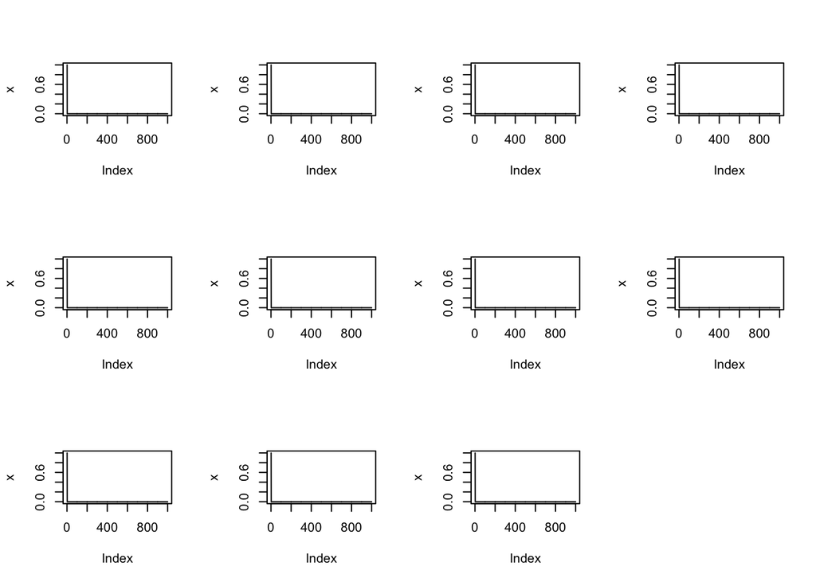

```r
#par(mfrow = c(3, 4)); apply(thetas, 2, hist)
par(mfrow = c(3, 4)); apply(thetas, 2, function(x) plot(x, type = "l"))
```

Here we see that the MCMC algorithm is simply setting all $\theta_j$ values to zero after a single gibbs iteration. This could be due to the $h = -100$ value. In either case, this MCMC algorithm is suggesting that *none* of the SNPs considered in this model effect the disease status $Y_i$. Regardless of this fact, we investigate the $\beta$ and $\beta_0$ samples below. We begin with $\beta_0$.

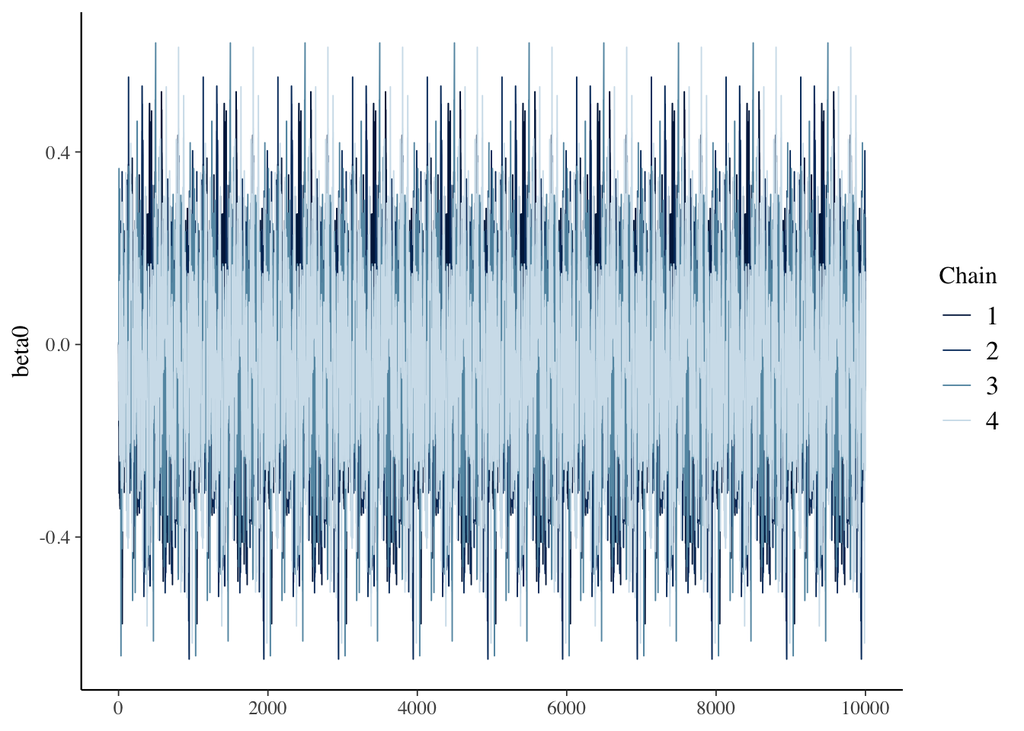

```r
#visual results using STAN
library(bayesplot)
mcmc_array <- function (ns, nchains, params) {
  nparams <- length(params)
  array(dim = c(ns, nchains, nparams),
        dimnames = list(iterations = NULL,
                        chains = paste0("chain", 1:nchains),
                        parameters = params))
}
set.seed(1985)
ns <- 10000
nchains <- 4
sims <- mcmc_array(ns, nchains, "beta0")
for (ic in 1:nchains)
  sims[, ic, ] <- get_beta0(X,Y)

rhat <- function (sims, ...)
  rstan::monitor(sims, print = FALSE, ...)[, "Rhat"]
neff_ratio <- function (sims, ...)
  rstan::monitor(sims, print = FALSE, ...)[, "n_eff"]

mcmc_trace(sims)
```

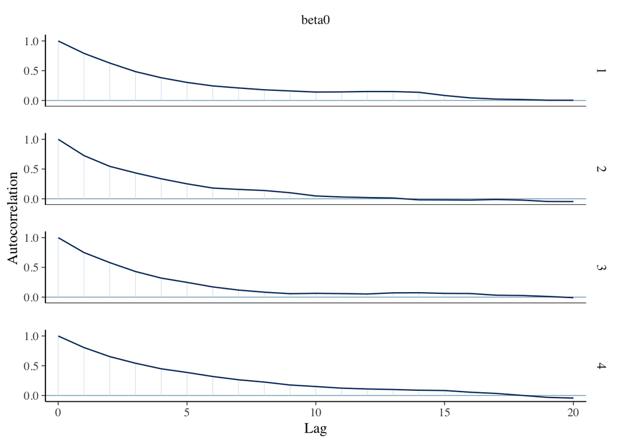

```r
mcmc_acf(sims)
```

```r
rhat(sims)
```

```
## [1] 1.002339
```

```r
neff_ratio(sims)
```

```
## [1] 2301.923
```

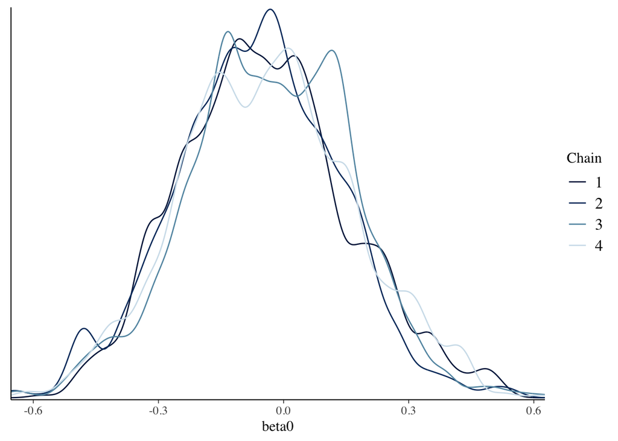

```r
mcmc_dens_overlay(sims)
```

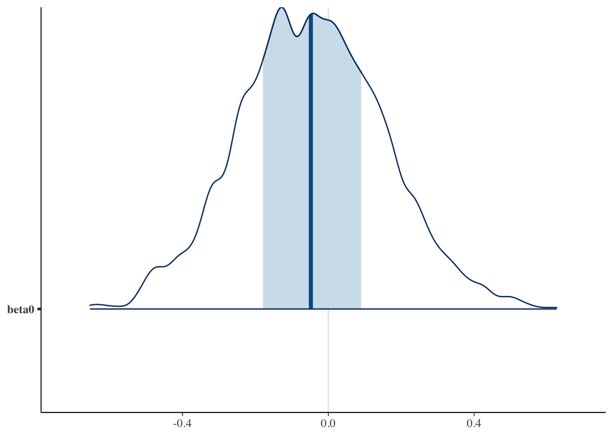

```r
mcmc_areas(sims)
```

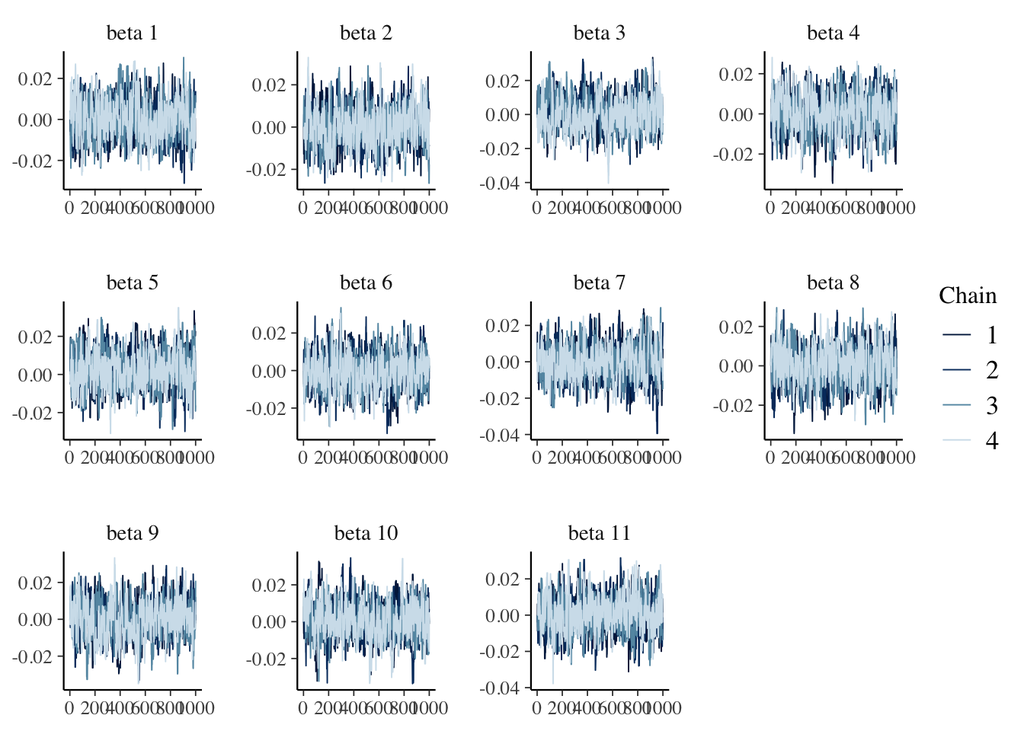

```r
#visual results using STAN
set.seed(1985)
ns <- 1000
nchains <- 4
sims <- mcmc_array(ns, nchains, c(sapply(1:11, function(x) paste("beta", x))))
for (ic in 1:nchains)
  sims[, ic, ] <- get_betas(X,Y)


rhat <- function (sims, ...)
  rstan::monitor(sims, print = FALSE, ...)[, "Rhat"]
neff_ratio <- function (sims, ...)
  rstan::monitor(sims, print = FALSE, ...)[, "n_eff"]

mcmc_trace(sims)
```

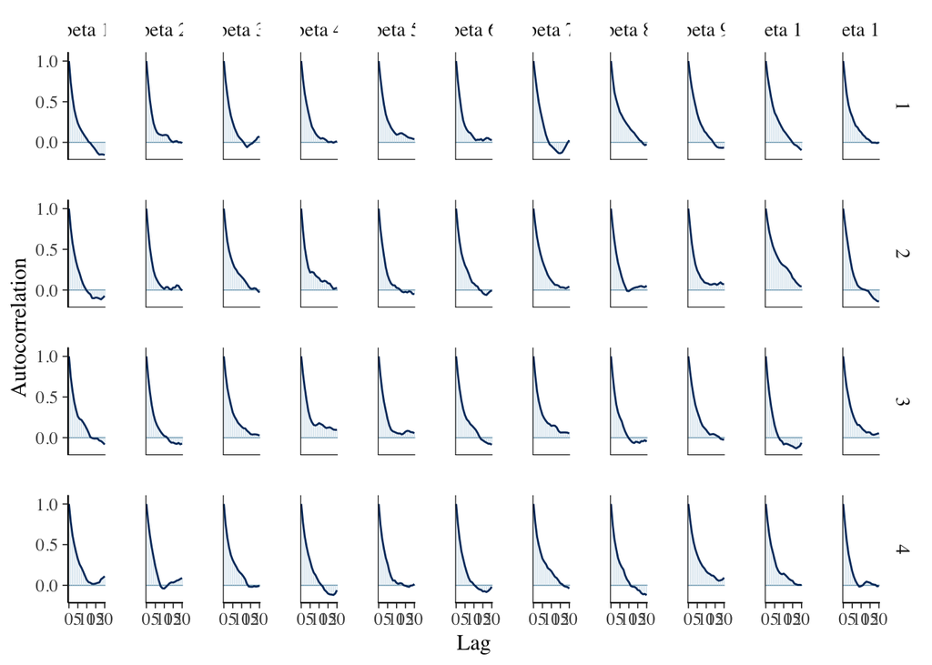

```r
mcmc_acf(sims)
```

```r
rhat(sims)
```

```
##   beta 1   beta 2   beta 3   beta 4   beta 5   beta 6   beta 7   beta 8
## 1.002399 1.015864 1.025306 1.013525 1.023976 1.019039 1.028973 1.011202
##   beta 9  beta 10  beta 11
## 1.011469 1.016922 1.012871
```

```r
neff_ratio(sims)
```

```
##   beta 1   beta 2   beta 3   beta 4   beta 5   beta 6   beta 7   beta 8
## 277.0511 340.5130 225.2310 250.0605 236.5313 245.9466 202.9673 308.9607
##   beta 9  beta 10  beta 11
## 233.7993 229.9217 239.2705
```

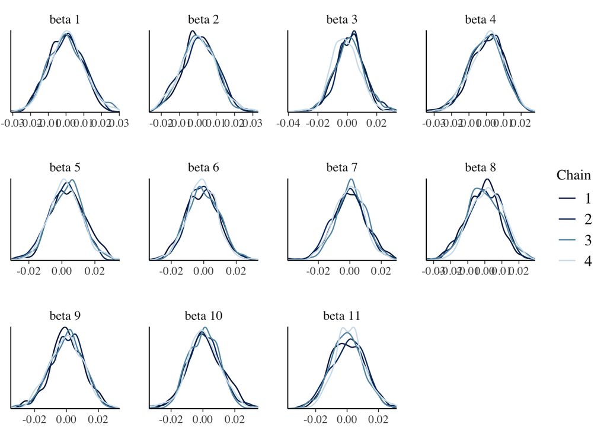

```r
mcmc_dens_overlay(sims)
```

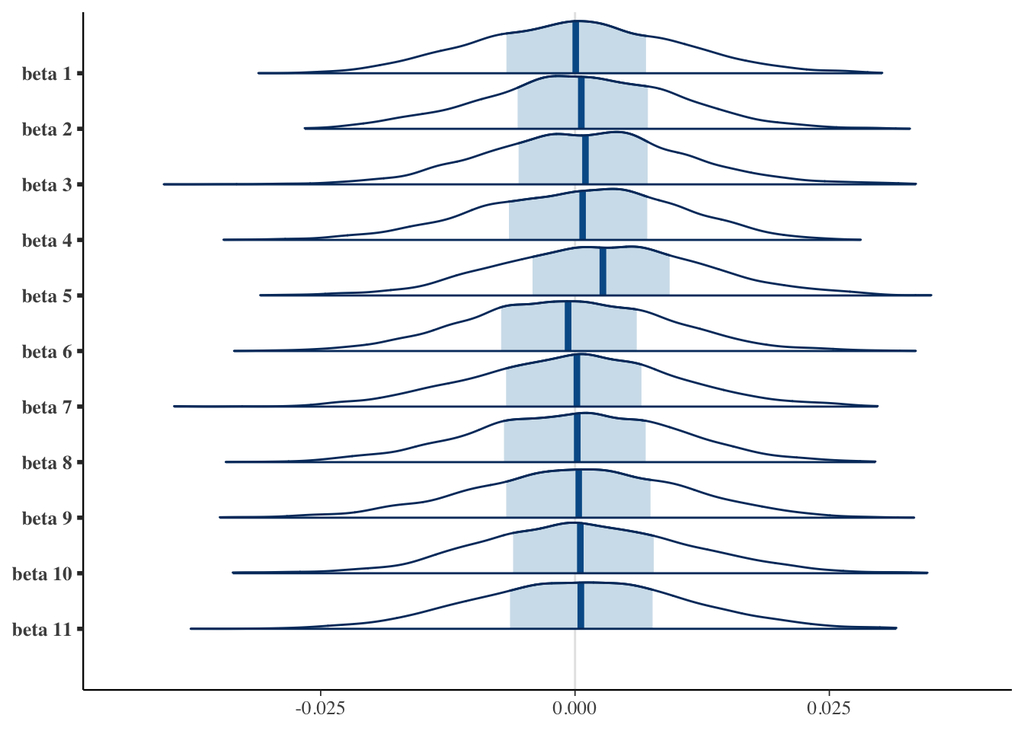

```r
mcmc_areas(sims)
```

Lastly we look to understand the convergence of the log posterior $\log\mathbb{P}(\theta, \beta, \beta_0|Y)$. First consider the following decomposition

$$\begin{align*}
\log\mathbb{P}(\theta, \beta, \beta_0|Y) &\propto \log\mathbb{P}(\beta_0|Y) + \log\mathbb{P}(\beta, \theta|Y)\\
&\propto \log\mathbb{P}(\beta_0|Y) + \log\mathbb{P}(\beta| \theta, Y) + \log\mathbb{P}(\theta|Y)
\end{align*}$$

Here we see that this is approximately equivalent to summing the posterior probabilities of each proposal step in the Gibbs model. We plot the trace plot and acf plot of these probabilities below.

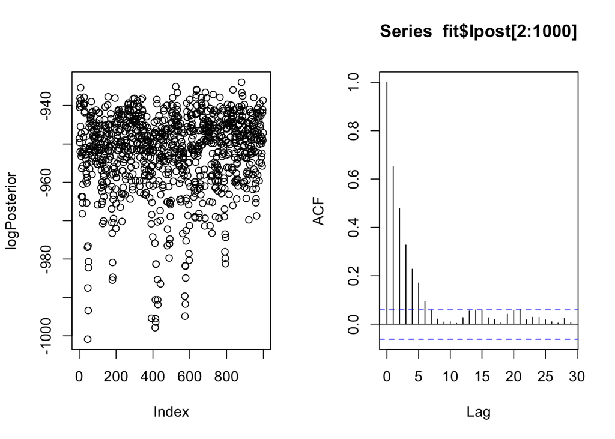

```r
set.seed(1985)
fit <- fit_mcmc(X,Y)
par(mfrow = c(1,2))
plot(fit$lpost[2:1000], ylab = "logPosterior")
acf(fit$lpost[2:1000])
```